# Analyses and Insights

```
At this point, 'WeRateDogs twitter archive' is wrangled through 3 dataframes and later join after cleaning acts to form a master dataframe 'twitter_archive_master.csv'.
After wrangling and analysis, we found some useful insights about the twitter archive which we will further discuss on.
some of its findings are: -
```

- Common Dog types
- Top rated dogs
- common Dog names
- Top most liked dogs
- Most retweeted dog

[figure not shown]

## common Dog types

- implementing the value count function of pandas on the dog_prediction column, we can find that the types; *'Pembroke', 'Chihuahua', 'Pug', 'Labrador Retriever'* are one of the more common dog types having a use score average of 50 - 90 near a hundred.
- The most common Dog type is the *"Golden Retriever"* with a use score of 139. This makes it the most popular dog type in the area.

## common Dog names

- __There are lots of names given to dogs, a ton of them even so in this contex but however, the are common dog names that we use or assign to our pets more often than not. Some of the high end number of dogs who bear common / same names;

  ```
     *Lucy*
     *Charlie*
     *Cooper*
     *Tucker*
     *Oliver*__
  ```

- The not so common names we tend give our dogs are;

  ```
       *Klein
       DonDon
       Chevy
       Philbert
       Christoper
  ```

  - ... and many others, dogs are cuties and have lots of human needed qualities. They do deserve the best names.

# Top rated Dogs

- We analyzed and can examine from the query of the dog_prediction column that although the *Golden retriever* may be well known and appretiated dog type, the *'Pembroke'* tends to be the highest rated among the dog types with a score count of *4* with the *'French Bulldog'* sharing a score of 2 counts with the *'Golden Retriever'*.

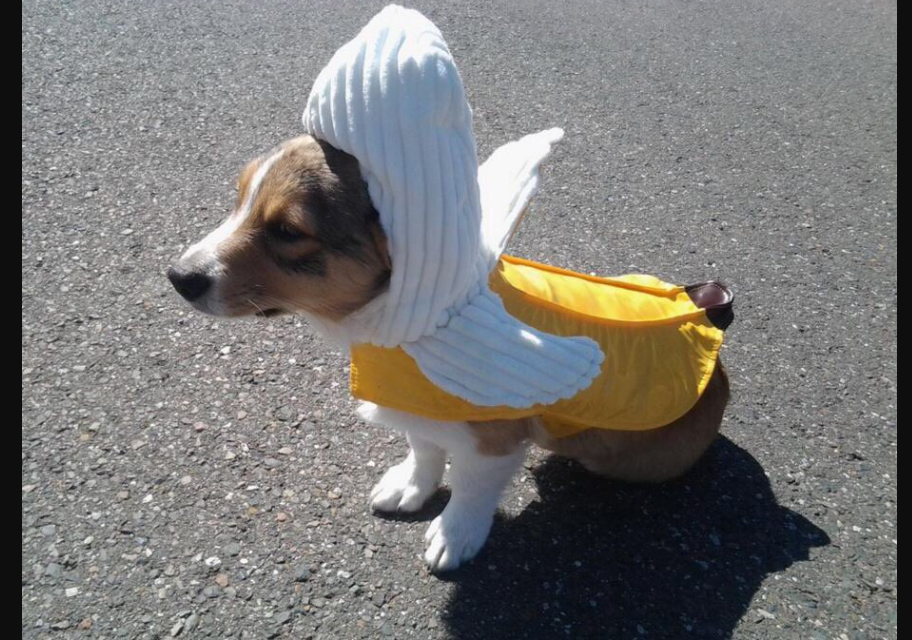

# Top Most liked Dogs

- **The Golden Retriever breed is not too far from the highlights, it comes top having the most like counts with the *Labrador Retriever, Pembroke Chihuahua Samoyed* following as one of the top liked dogs in the area.**

  ```
     Golden Retriver     - 1696627
     Labrador Retriever  - 1123850
     Pembroke            - 994755
     Chihuahua           - 676441
     Samoyed             - 542991
  ```

[figure not shown]

# Top retweeted breed of dogs

- **Its no surprise here that the set of most liked dogs remain in this section of the analyses. It can be argued that on tweeter, retweets mean more than likes, could mean it is more funny, cute or an interesting tweet about the breed.**

  ```
    Golden Retriever    -  502096
    Labrador Retriever  -  366682
    Pembroke            -  280367
    Chihuahua           -  220695
    Samoyed             -  184922
  ```

# Visualizations and Plots

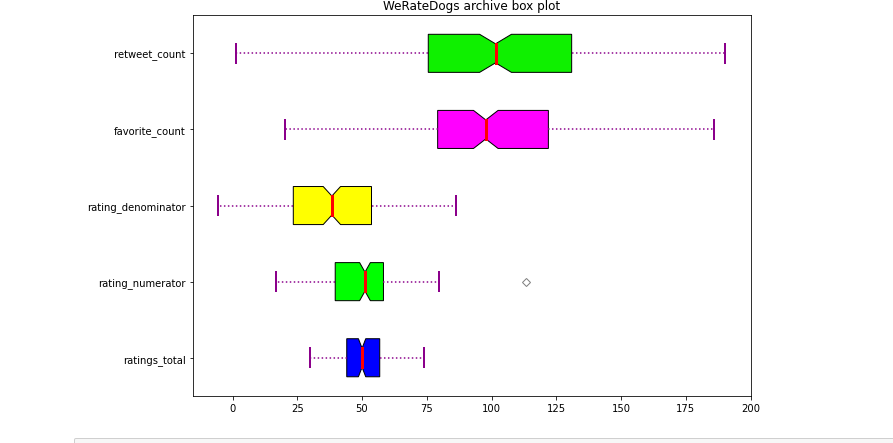